# Narrative of original analysis

Renata Diaz  
5/27/2019

A walkthrough of Ernest (2005)'s original analytical approach, from close reading of the paper.

## Questions

1. Is energy use across body size categories (regardless of species) uniform or multimodal?
- uniform would correspond generally to energetic equivalence/Damuth's rule.
- multimodal might suggest different resource availability for different body sizes.
1. If energy use is not uniform across body size categories, does the species level body size distribution correspond to modes of energy use?
- i.e. are there more species with mean body sizes around the modes of the body size-energy use distribution?
- if so, maybe it's good to be certain sizes, and species accumulate at those optima.

## Data

#### Ernest data

Ernest drew data from the Andrews LTER in the Willamette National Forest, Oregon, the Sevilleta LTER in the Chihuahuan desert, Niwot Ridge LTER in alpine tundra, and the Portal project in the Chihuahuan desert. For details of these field sites, see the *Ernest (2005).*

#### Translation to `replicate-becs`

The same datasets are available online; see Citations, below, for links.

Rather than download them through the host websites, they are included in `replicate-becs`. (To download them from their original hosts, use `from_url = TRUE`.) By default they will be stored in `replicate-becs/working-data/paper/raw`.

```r
download_raw_paper_data(from_url = FALSE)
```

```
## [1] TRUE
```

Process raw data into the appropriate format. This is a data table with a record for each individual and columns for `species` and `weight` in grams. By default these tables will be stored in subdirectores of `replicate-becs/working-data/paper/processed`.

```r
process_raw_data()
```

```
## Loading in data version 1.107.0

## [1] TRUE
```

Load data tables for each community.

```r
communities <- load_paper_data()
```

Each community is a named data table with columns for species and size for each individual, for example:

```r
names(communities)[[1]]
```

```
## [1] "andrews"
```

```r
head(communities[[1]])
```

```
##   individual_species_ids individual_sizes
## 1                   SOTR              4.0
## 2                   PEMA             16.5
## 3                   GLSA            167.0
## 4                   MIOR             13.0
## 5                   PEMA             14.0
## 6                   GLSA            142.0
```

#### Comparing data from 2005 to data available in 2019

Although the same datasets are now available online, they may have changed somewhat since 2005 (due to error checking, etc). Ernest (2005) may also have taken some cleaning and filtering steps, the details of which could have been omitted from the manuscript due to length restrictions. For example, many studies using data from the Portal Project omit ground squirrels, because although they may be within the "small mammal" size range, they are not target taxa for the sampling method.

Ernest (2005) reported summary statistics of the datasets; here I compare them to the corresponding dataset in the 2019 data.

```r
summary_stats_comparison = compare_summary_stats()

print(summary_stats_comparison)
```

```
##          ernest_name     new_name ernest_richness new_richness
## 1            andrews      andrews               9            9
## 2              niwot        niwot              11           11
## 3             portal       portal              21           19
## 4          sev grass  sev-5pgrass              18           15
## 5    sev grass shrub  sev-rsgrass              20           18
## 6        sev juniper    sev-two22              21           18
## 7 sev pinyon juniper sev-goatdraw              12           12
## 8          sev shrub sev-5plarrea              18           15
## 9        sev shrub 2 sev-rslarrea              20           20
##   ernest_min_mass new_min_mass ernest_max_mass new_max_mass
## 1            4.46     4.482840             140     140.0000
## 2            4.00     4.000000             194     194.5000
## 3            7.70     6.000000             157     155.4813
## 4            7.37     7.267399             152     177.6000
## 5            7.37     7.267399             152     177.6000
## 6            7.37     7.267399             152     177.6000
## 7            7.37     7.267399             152     177.6000
## 8            7.37     7.267399             152     177.6000
## 9            7.37     7.267399             152     177.6000
```

## Constructing distributions/metrics

### Body size-energy use distributions (BSED)

#### Ernest method

- Per individual, calculate metabolic rate as metabolic rate $B \propto M^\frac{3}{4}$ where *M* is mass in grams.
- Sum energy use of all individuals in body size classes of .2 natural log units.
- Also try classes of .1 and .3 natural log units
- Convert raw energy use values for each body size class into the proportion of all the energy used in that community used by that body size class. This allows for comparisons between communities.

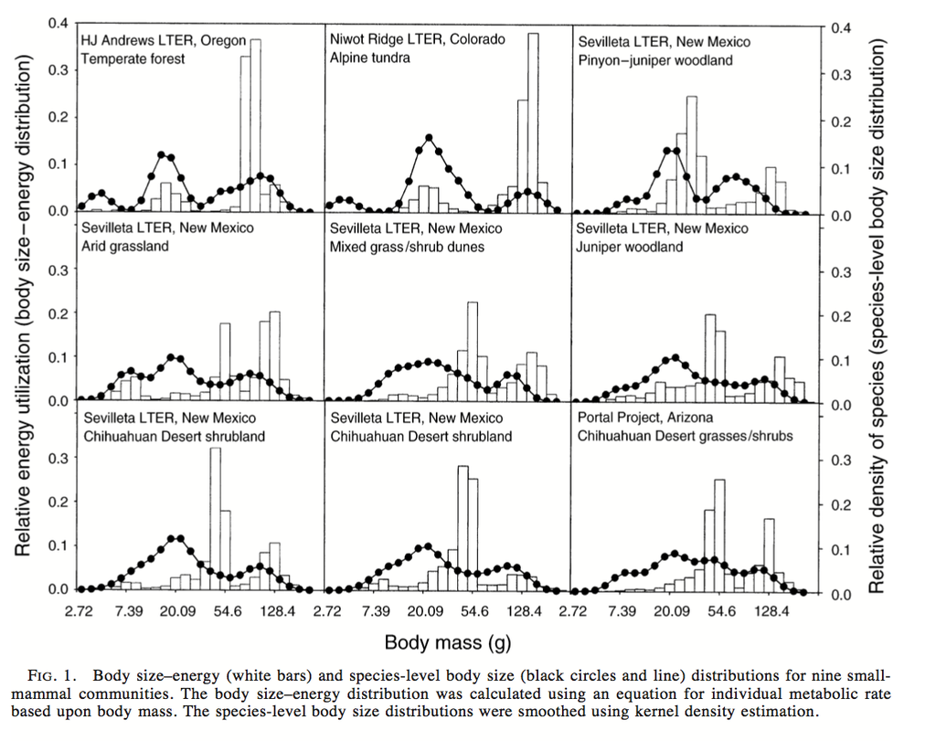

#### Translation to `replicate-becs`

For every individual, calculate metabolic rate and assign to a size class.

```r
communities_energy <- lapply(communities, FUN = add_energy_sizeclass, ln_units = 0.2)

head(communities_energy[[1]])
```

```
##   individual_species_ids individual_sizes individual_energy size_class
## 1                   SOTR              4.0          2.828427        1.2
## 2                   PEMA             16.5          8.186777        2.8
## 3                   GLSA            167.0         46.455523        5.0
## 4                   MIOR             13.0          6.846325        2.4
## 5                   PEMA             14.0          7.237624        2.6
## 6                   GLSA            142.0         41.135451        4.8
##   size_class_g
## 1     3.320117
## 2    16.444647
## 3   148.413159
## 4    11.023176
## 5    13.463738
## 6   121.510418
```

For each community, sum total energy use for each size class, and convert to the proportion of total energy use for that community.

```r
bseds <- lapply(communities_energy, FUN = make_bsed)

head(bseds[[1]])
```

```
## # A tibble: 6 x 4
##   size_class size_class_g total_energy total_energy_proportional
##        <dbl>        <dbl>        <dbl>                     <dbl>
## 1        0.6         1.82         1.68                  0.000211
## 2        1           2.72        20.6                   0.00259
## 3        1.2         3.32       239.                    0.0301
## 4        1.4         4.06        49.4                   0.00621
## 5        1.6         4.95       195.                    0.0246
## 6        1.8         6.05        21.1                   0.00265
```

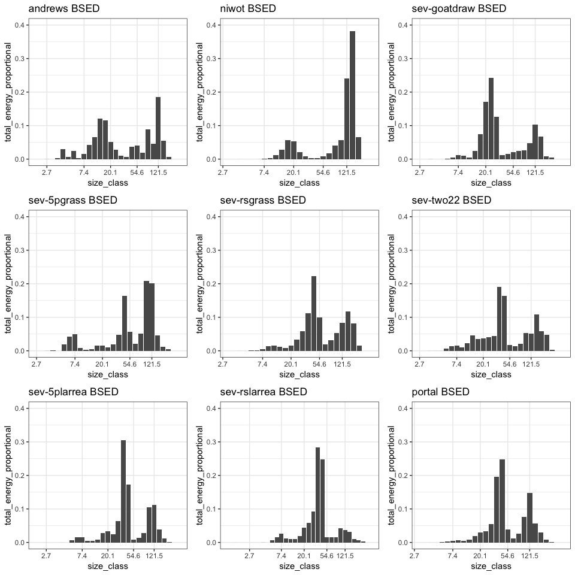

### Species-level body size distributions (BSD)

#### Ernest method

- Frequency distributions of mean mass of each species in a community.
- For plotting (but not statistics), smoothed using kernel density estimation.
- Gaussian kernel to mimic the actual body size distribution in log space
- avg. std dev of the mean of the logged masses = smoothing parameter *h*
- align sampling points with the midpoint of each size class in the BSED
- after Manly 1996, "Are there clumps in body-size distributions?", *Ecology*

#### Translation to `replicate-becs`

Calculate mean mass of each species in each community.

```r
bsds <- lapply(communities, FUN = make_bsd)

head(bsds[[1]])
```

```
## # A tibble: 6 x 6
##   individual_specie… species_mean_ma… ln_mass size_class size_class_g stdev
##   <chr>                         <dbl>   <dbl>      <dbl>        <dbl> <dbl>
## 1 CLCA                           17.9    2.88        2.8        16.4   1.19
## 2 GLSA                          117.     4.76        4.6        99.5   1.19
## 3 MIOR                           14.9    2.70        2.6        13.5   1.19
## 4 NEGI                            6.5    1.87        1.8         6.05  1.19
## 5 PEMA                           14.9    2.70        2.6        13.5   1.19
## 6 SCOR                           54.4    4.00        3.8        44.7   1.19
```

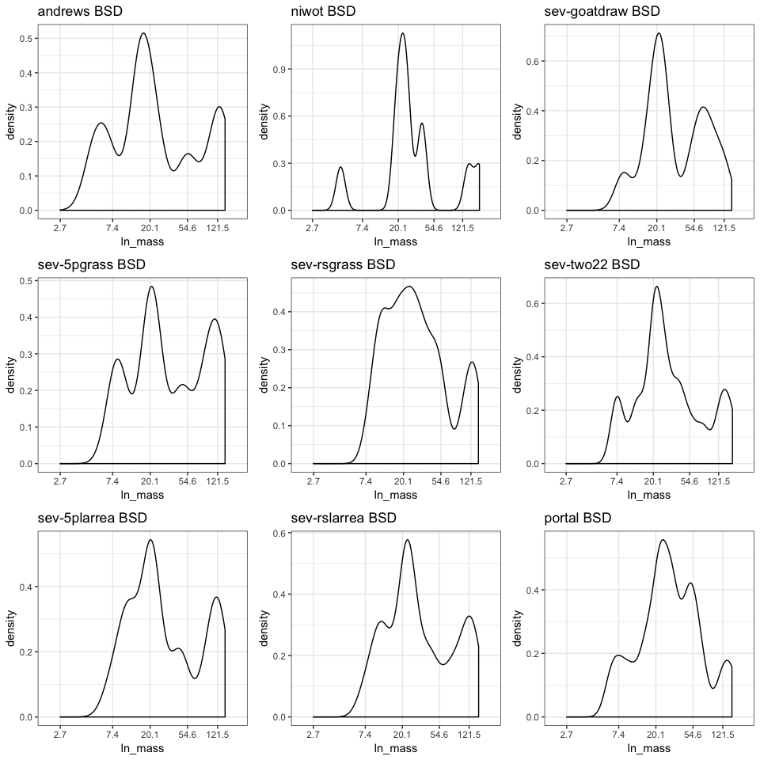

### Energetic dominance (*D*<sub>*E*</sub>)

- Define "energy use modes" as contiguous body size classes where the energy use of each size class > 5% of the community total.
- i.e. a little bit more than the expectation if energy use is uniform across all body sizes
- Calculate the total energy use for each species in the mode.
- Calculate the "dominance" of the species with the highest energy use in that mode as *D*<sub>*E*</sub> = *p*<sub>*m**a**x*</sub>, where *p*<sub>*m**a**x*</sub> is the maximum proportion of energy use by any one species in a mode.
- "a modification of the Berger-Parker dominance index (Berger and Parker 1970)"

#### Translation to `replicate-becs`

- Find contiguous size classes where each class has >5% of total energy use
- Calculate the total energy use for each species, and the proportion held by the species with the highest energy use (*p*<sub>*m**a**x*</sub>)
- Return *p*<sub>*m**a**x*</sub> for every mode, along with the min and max size classes in that mode for each community

```r
energetic_dom <- lapply(communities_energy, FUN = energetic_dominance)

head(energetic_dom[[1]])
```

```
## # A tibble: 3 x 4
##   mode_id e_dominance size_class_min size_class_max
##     <dbl>       <dbl>          <dbl>          <dbl>
## 1       1       0.766            2.4            3
## 2       2       1                4.4            4.4
## 3       3       0.979            4.8            5
```

- To plot, combine all modes from all communities and plot a histogram of *D*<sub>*E*</sub> values.

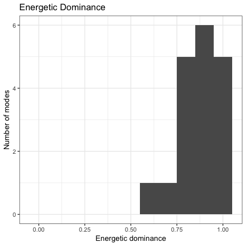

## Statistical tests

### Comparing BSEDs to uniform

#### Translation to `replicate-becs`

```r
bsed_unif_sizeabund_bootstraps <- lapply(communities, FUN = draw_bootstrap_samples,  assumption = 'bootstrap_unif_size_abund', nbootstraps = 10000)
```

*See issue #4 on github.*

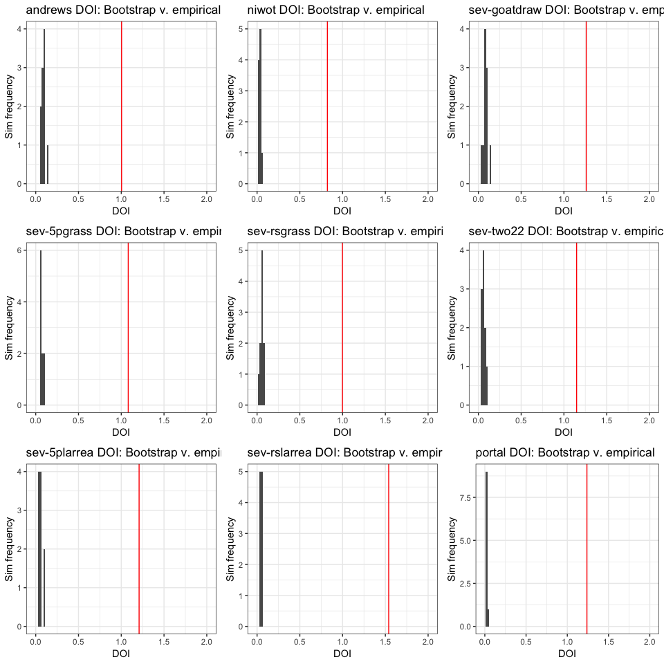

### Compare BSEDs among communities

#### Ernest approach

- For every pair of communities, create a pool of masses of all individuals from both communities.
- Draw two new communities with the same number of individuals as the empirical communities, pulling masses at random from the pool, with replacement.
- Calculate the DOI for the BSEDs of the two sample communities.
- Repeat 10000 for each pair.
- The P value is the proportion of sample DOIs greater (i.e. less overlap) than the empirical value.

#### Translation to `replicate-becs`

```r
community_pairs <- setup_community_combinations(communities)
```

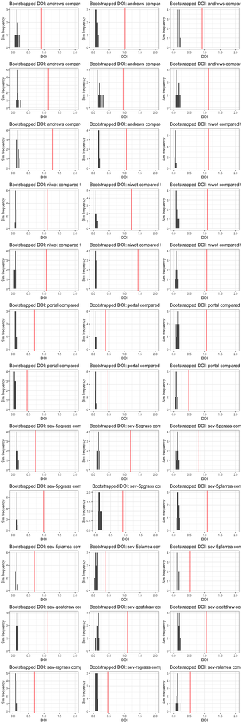

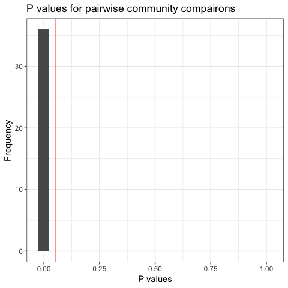

```r
bsed_crosscomm_samples <- lapply(community_pairs, FUN = draw_bootstrap_samples,  assumption = 'cross_communities', nbootstraps = 10000)
```

### Testing BSDs for uniformity

#### Ernest approach

- *δ*-corrected Kolmogorov-Smirnov test.
- "The *δ*-corrected K-S test increases the power of the test when sample sizes are small (n < 25; Zar 1999)"
- The *δ*-corrected test is not widely discussed online.

```r
appendixA <- load_ernest_appendixA()
print(appendixA)
```

```
##                 site sample.size     d delta p_min p_max signif
## 1            andrews           9 0.210     1   0.5   1.0  FALSE
## 2              niwot          11 0.290     1   0.1   0.2  FALSE
## 3             portal          21 0.090     1   0.5   1.0  FALSE
## 4          sev grass          18 0.175     0   0.2   0.5  FALSE
## 5    sev grass shrub          20 0.102     0   0.5   1.0  FALSE
## 6        sev juniper          21 0.115     0   0.5   1.0  FALSE
## 7 sev pinyon juniper          12 0.120     0   0.5   1.0  FALSE
## 8          sev shrub          18 0.189     0   0.2   0.5  FALSE
## 9        sev shrub 2          20 0.137     0   0.5   1.0  FALSE
##   community_name
## 1        andrews
## 2          niwot
## 3         portal
## 4    sev-5pgrass
## 5    sev-rsgrass
## 6      sev-two22
## 7   sev-goatdraw
## 8   sev-5plarrea
## 9   sev-rslarrea
```

#### Translation to `replicate-becs`:

*From Zar (1999)* Biostatistical Analysis*.*

##### Base K-S test

- Take vector of measurements *X*<sub>*i*</sub>.
- For each *X*<sub>*i*</sub> record the observed frequency *f*<sub>*i*</sub> (number of observations with that value).
- Determine cumulative observed frequencies *F*<sub>*i*</sub> and cumulative relative frequencies rel*F*<sub>*i*</sub>:
- $\textrm{rel}F_i = \frac{F_i}{n}$ where *n* is the number of measurements taken.
- rel*F*<sub>*i*</sub> is the proportion of the sample that is measurements ≤*X*<sub>*i*</sub>.
- For each *X*<sub>*i*</sub>, determine the cumulative *relative* expected frequency from the comparison distribution, $\textrm{rel}\hat{F_i}$.
- For a uniform distribution, $\textrm{rel}\hat{F_i} = \frac{X_i - \min(X)}{\max(X) - \min(X)}$
- Determine *D*<sub>*i*</sub> and *D*′<sub>*i*</sub> as:
- $D_i = |{\textrm{rel}F_i - \textrm{rel}\hat{F_i}}|$
- $D'_i = |{\textrm{rel}F_{i-1} - \textrm{rel}\hat{F_i}}|$
- note *F*<sub>0</sub> = 0 so $D'_1 = \textrm{rel}\hat{F_i}$
- The test statistic *D* is:
- *D* = max[(max(*D*<sub>*i*</sub>),(max(*D*′<sub>*i*</sub>)]
- Compare to critical values from appendix.

##### *δ*-corrected KS test

- For small sample sizes (<25) we can obtain increased power using the *δ*-corrected KS test.
- For each *i* determine
- $\textrm{rel}G_i = \frac{F_i}{n + 1}$
- $\textrm{rel}G'_i = \frac{F_i - 1}{n - 1}$
- Then obtain similar *D*s
- $D_{0, i} = |\textrm{rel}G_i - \textrm{rel}\hat{F_i}|$
- $D_{1, i} = |\textrm{rel}G'_i - \textrm{rel}\hat{F_i}|$
- The test statistic is either max(*D*<sub>0, *i*</sub>) or max(*D*<sub>1, *i*</sub>), whichever leads to the highest level of significance/smallest probability. Look up significance in table from appendix. The 1 and 0 are the *δ*s.

Tables of critical values were entered by hand from the appendix to Zar (1999).

```
##   community_name signif.x p_max.x p_min.x d_statistic               site
## 1        andrews     TRUE    0.02       0   0.4824239            andrews
## 2          niwot     TRUE    0.02       0   0.6140682              niwot
## 3         portal     TRUE    0.02       0   0.4946621             portal
## 4    sev-5pgrass     TRUE    0.02       0   0.3893173          sev grass
## 5   sev-5plarrea     TRUE    0.02       0   0.4624160          sev shrub
## 6   sev-goatdraw     TRUE    0.02       0   0.3881576 sev pinyon juniper
## 7    sev-rsgrass     TRUE    0.02       0   0.4672033    sev grass shrub
## 8   sev-rslarrea     TRUE    0.02       0   0.4343417        sev shrub 2
## 9      sev-two22     TRUE    0.02       0   0.5084637        sev juniper
##   sample.size     d delta p_min.y p_max.y signif.y
## 1           9 0.210     1     0.5     1.0    FALSE
## 2          11 0.290     1     0.1     0.2    FALSE
## 3          21 0.090     1     0.5     1.0    FALSE
## 4          18 0.175     0     0.2     0.5    FALSE
## 5          18 0.189     0     0.2     0.5    FALSE
## 6          12 0.120     0     0.5     1.0    FALSE
## 7          20 0.102     0     0.5     1.0    FALSE
## 8          20 0.137     0     0.5     1.0    FALSE
## 9          21 0.115     0     0.5     1.0    FALSE
```

The *δ* corrected KS test does not correspond to the results from Ernest when the species mean body size values are on an untransformed scale.

Using the natural log of the species mean body size value, however...:

```
##   community_name signif.x p_max.x p_min.x d_statistic               site
## 1        andrews    FALSE     1.0     0.5   0.1398433            andrews
## 2          niwot    FALSE     0.5     0.1   0.2973462              niwot
## 3         portal    FALSE     1.0     0.5   0.1436705             portal
## 4    sev-5pgrass    FALSE     1.0     0.5   0.1252882          sev grass
## 5   sev-5plarrea    FALSE     0.5     0.1   0.2037134          sev shrub
## 6   sev-goatdraw    FALSE     1.0     0.5   0.1327084 sev pinyon juniper
## 7    sev-rsgrass    FALSE     1.0     0.5   0.1617653    sev grass shrub
## 8   sev-rslarrea    FALSE     1.0     0.5   0.1415647        sev shrub 2
## 9      sev-two22    FALSE     1.0     0.5   0.1663774        sev juniper
##   sample.size     d delta p_min.y p_max.y signif.y
## 1           9 0.210     1     0.5     1.0    FALSE
## 2          11 0.290     1     0.1     0.2    FALSE
## 3          21 0.090     1     0.5     1.0    FALSE
## 4          18 0.175     0     0.2     0.5    FALSE
## 5          18 0.189     0     0.2     0.5    FALSE
## 6          12 0.120     0     0.5     1.0    FALSE
## 7          20 0.102     0     0.5     1.0    FALSE
## 8          20 0.137     0     0.5     1.0    FALSE
## 9          21 0.115     0     0.5     1.0    FALSE
```

With mean mass logged, all the results replicate qualitatively (i.e. not significantly different from uniform) and Niwot, for which the currently-available data most closely matches that reported in Ernest (2005), replicates almost exactly numerically.

### Comparing BSDs among communities

#### Ernest approach

Ernest (2005) used a two-sample Kolmogorov-Smirnov test to compare every possible combination of community-level BSDs.

#### Translation to `replicate-becs`

```
##     community_b  community_a      ks_d   p_value             site_a
## 1       andrews        niwot 0.4646465 0.1651107              niwot
## 2       andrews       portal 0.2923977 0.5769685             portal
## 3       andrews  sev-5pgrass 0.3555556 0.3936294          sev grass
## 4       andrews sev-5plarrea 0.2888889 0.6408133          sev shrub
## 5       andrews sev-goatdraw 0.3888889 0.3445820 sev pinyon juniper
## 6       andrews  sev-rsgrass 0.2222222 0.9241602    sev grass shrub
## 7       andrews sev-rslarrea 0.3055556 0.4896041        sev shrub 2
## 8       andrews    sev-two22 0.3333333 0.5004034        sev juniper
## 9         niwot       portal 0.1866029 0.9182101             portal
## 10        niwot  sev-5pgrass 0.2848485 0.5642337          sev grass
## 11        niwot sev-5plarrea 0.3272727 0.4048195          sev shrub
## 12        niwot sev-goatdraw 0.2348485 0.8102121 sev pinyon juniper
## 13        niwot  sev-rsgrass 0.2979798 0.4827685    sev grass shrub
## 14        niwot sev-rslarrea 0.2181818 0.7988116        sev shrub 2
```

[output cut: 59 more lines]

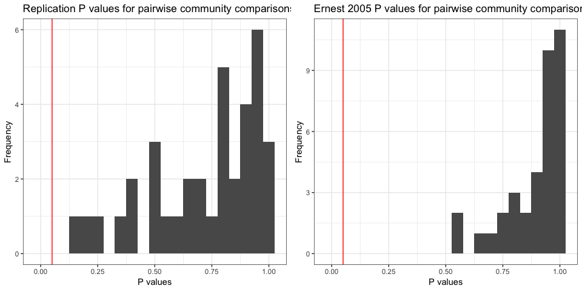

```r
# use same community combinations as before

bsd_crosscomm_ks <- lapply(community_pairs, FUN = ks_bsd,
                          ln_mass_vals = F)

ernest_twosampleks_comparison = compare_ernest_ks_values(bsd_crosscomm_ks)

print(ernest_twosampleks_comparison)
```

## Citations

Andrews LTER small mammal data: Garman, S.; McComb, B. 2002. Monitoring small mammal and amphibian abundances on the Willamette National Forest, Oregon (Long-Term Ecosystem Productivity experiment), 1995-1999. Long-Term Ecological Research. Forest Science Data Bank, Corvallis, OR. [Database]. Available: http://andlter.forestry.oregonstate.edu/data/abstract.aspx?dbcode=WE026 (28 May 2019).

Niwot Ridge LTER small mammal data: Halfpenny J. 1994. Small mammal herbivore trapping in alpine tundra. Environmental Data Initiative. https://doi.org/10.6073/pasta/f39ac94e1db31c8e313efea83d1e3859. Dataset accessed 5/28/2019.

Sevilleta LTER small mammal data: Newsome S. 2010. Small Mammal Mark-Recapture Population Dynamics at Core Research Sites at the Sevilleta National Wildlife Refuge, New Mexico (1989 - present). Environmental Data Initiative. https://doi.org/10.6073/pasta/cdd8f254ef97d854d6eb2efb7385b801. Dataset accessed 5/28/2019.

Portal Project data accessed using the `portalr` package: Glenda M. Yenni, Hao Ye, Erica M. Christensen, Juniper L. Simonis, Ellen K. Bledsoe, Renata M. Diaz, Shawn D. Taylor, Ethan P, White and S.K. Morgan Ernest (2019). portalr: Create Useful Summaries of the Portal Data. https://weecology.github.io/portalr/, https://github.com/weecology/portalr.

Zar, J.H. 1999. Biostatistical analysis. Fourth edition. Prentice Hall, Englewood Cliffs, New Jersey, USA.